# EDA Danych dotyczących Titanica

### Miejsce docelowe podróży (home.dest)

Kolumna home.dest wskazuje docelowe miejsce podróży – najczęściej miasta w USA, ale też niektóre lokalizacje w Europie. Sprawdzimy, czy miejsce docelowe wiązało się z przeżywalnością oraz czy pasażerowie 1 klasy kierowali się do konkretnych miast.

|  | name | title | sex | age | survived | sibsp | parch | body | pclass | cabin | ... | age_group | cabin_section | is_adult | group | has_family | family_size | group_size | fare_per_person | fare_bin | to_usa |
| --- | --- | --- | --- | --- | --- | --- | --- | --- | --- | --- | --- | --- | --- | --- | --- | --- | --- | --- | --- | --- | --- |
| 0 | Allen, Miss. Elisabeth Walton | Miss | female | 29.0000 | 1.0 | 0.0 | 0.0 | NaN | 1.0 | B5 | ... | Dorośli | B | True | Reszta dorosłych | False | 0.0 | 4 | 52.83 | Drogi (30-100) | False |
| 1 | Allison, Master. Hudson Trevor | Master | male | 0.9167 | 1.0 | 1.0 | 2.0 | NaN | 1.0 | C22 C26 | ... | Dzieci | C | False | Reszta dorosłych | True | 3.0 | 6 | 25.26 | Średni (10-30) | False |
| 2 | Allison, Miss. Helen Loraine | Miss | female | 2.0000 | 0.0 | 1.0 | 2.0 | NaN | 1.0 | C22 C26 | ... | Dzieci | C | False | Reszta dorosłych | True | 3.0 | 6 | 25.26 | Średni (10-30) | False |
| 3 | Allison, Mr. Hudson Joshua Creighton | Mr | male | 30.0000 | 0.0 | 1.0 | 2.0 | 135.0 | 1.0 | C22 C26 | ... | Dorośli | C | True | Reszta dorosłych | True | 3.0 | 6 | 25.26 | Średni (10-30) | False |
| 4 | Allison, Mrs. Hudson J C (Bessie Waldo Daniels) | Mrs | female | 25.0000 | 0.0 | 1.0 | 2.0 | NaN | 1.0 | C22 C26 | ... | Dorośli | C | True | Reszta dorosłych | True | 3.0 | 6 | 25.26 | Średni (10-30) | False |
| ... | ... | ... | ... | ... | ... | ... | ... | ... | ... | ... | ... | ... | ... | ... | ... | ... | ... | ... | ... | ... | ... |
| 1304 | Zabour, Miss. Hileni | Miss | female | 14.5000 | 0.0 | 1.0 | 0.0 | 328.0 | 3.0 | Nieprzydzielona | ... | Dzieci | N | False | Reszta dorosłych | True | 1.0 | 2 | 7.23 | Tani (<10) | False |
| 1305 | Zabour, Miss. Thamine | Miss | female | 28.0000 | 0.0 | 1.0 | 0.0 | NaN | 3.0 | Nieprzydzielona | ... | Dorośli | N | True | Reszta dorosłych | True | 1.0 | 2 | 7.23 | Tani (<10) | False |
| 1306 | Zakarian, Mr. Mapriededer | Mr | male | 26.5000 | 0.0 | 0.0 | 0.0 | 304.0 | 3.0 | Nieprzydzielona | ... | Dorośli | N | True | Reszta dorosłych | False | 0.0 | 1 | 7.22 | Tani (<10) | False |
| 1307 | Zakarian, Mr. Ortin | Mr | male | 27.0000 | 0.0 | 0.0 | 0.0 | NaN | 3.0 | Nieprzydzielona | ... | Dorośli | N | True | Reszta dorosłych | False | 0.0 | 1 | 7.22 | Tani (<10) | False |
| 1308 | Zimmerman, Mr. Leo | Mr | male | 29.0000 | 0.0 | 0.0 | 0.0 | NaN | 3.0 | Nieprzydzielona | ... | Dorośli | N | True | Reszta dorosłych | False | 0.0 | 1 | 7.88 | Tani (<10) | False |

1309 rows × 26 columns

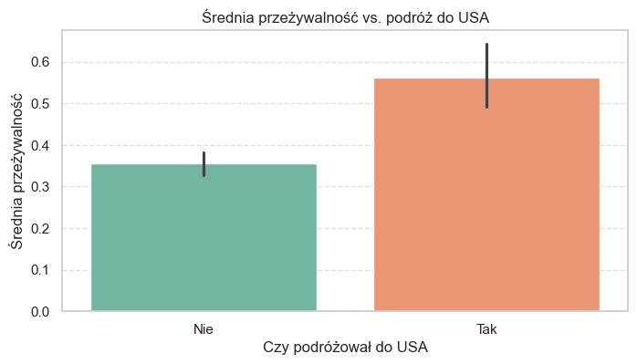

Osoby podróżujące do USA miały wyraźnie wyższą przeżywalność – można przypuszczać, że byli to zamożniejsi pasażerowie (np. Amerykanie wracający do domu, obywatele USA), często w wyższych klasach.

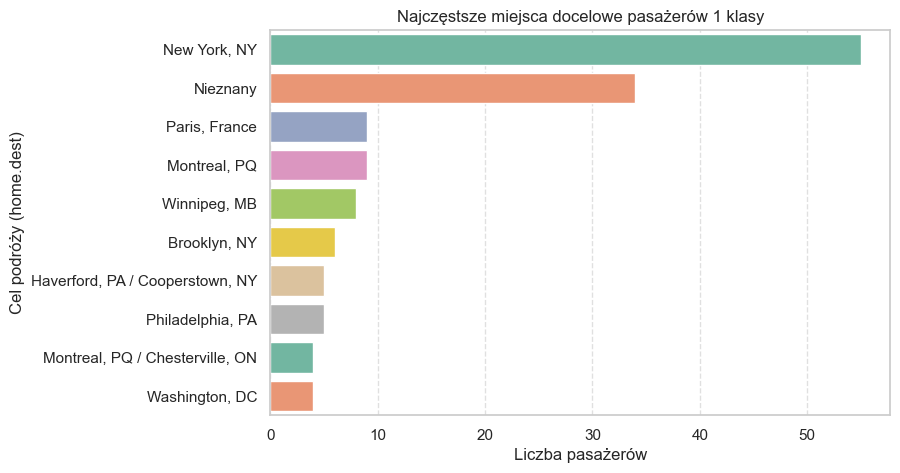

Możemy zauważyć, że cel podróży był powiązany z klasą oraz prawdopodobnie z poziomem zamożności – co mogło mieć wpływ na dostęp do szalup ratunkowych.

### Numer łodzi ratunkowej (boat)

Kolumna boat zawiera numery łodzi ratunkowych, do których przydzielono pasażerów. Brak informacji (nie przypisano łodzi) oznacza osoby, które nie zostały przypisane do żadnej łodzi (z dużym prawdopodobieństwem – osoby, które nie przeżyły).

Sprawdzimy m.in.:

Ile było użytych różnych łodzi?

Czy niektóre łodzie były bardziej „przepełnione” (czyli bardziej popularne)?

Czy konkretne klasy miały przypisane konkretne łodzie?

Czy wszystkie łodzie były używane równomiernie?

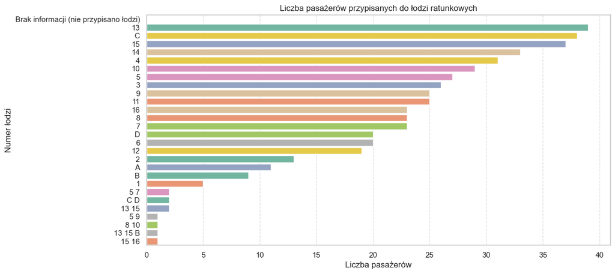

Podsumowująć łodzie nie były używane równomiernie – część z nich miała więcej pasażerów.

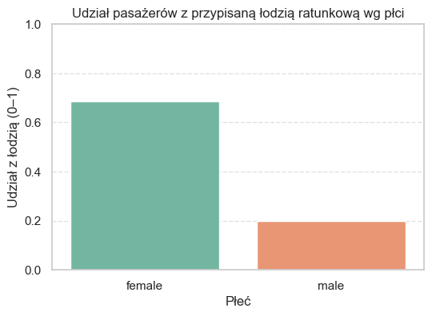

Kobiety miały znacznie większe szanse na przypisanie do łodzi ratunkowej niż mężczyźni. Potwierdza to zasadę: „kobiety i dzieci pierwsze” podczas ewakuacji.

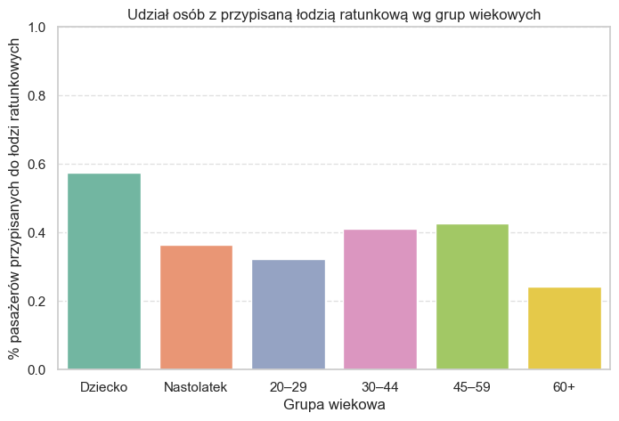

Dzieci (0–12 lat) miały zdecydowanie większe szanse na przypisanie do łodzi ratunkowej, co pasuje do zasady „kobiety i dzieci pierwsze”.

Osoby w wieku 60+ miały mniejsze szanse na przypisanie do łodzi ratunkowej niż inne grupy wiekowe, co może wskazywać na:

- niższy priorytet ewakuacji,
- gorszą mobilność w sytuacjach kryzysowych, która utrudniała szybkie dotarcie do łodzi.

Osoby w wieku 20–44 lata również miały mniejsze szanse na przypisanie do łodzi, co sugeruje, że:

- były traktowane jako bardziej zdolne do samodzielnej ewakuacji,
- mogły pozostać na pokładzie w celu umożliwienia ewakuacji innych.

Dodatkowy wykres porównujący kobiety i dzieci vs. wszyscy inni

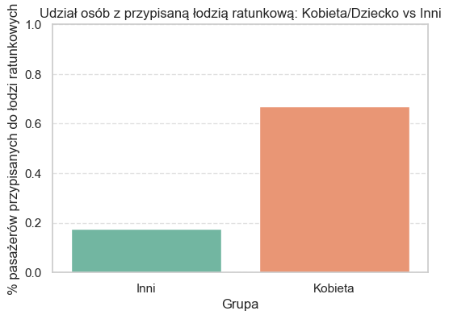

Kobiety i dzieci mają zdecydowanie większy udział przypisania do łodzi – potwierdzenie zasady „kobiety i dzieci pierwsze”.

Inni (mężczyźni i osoby >12 lat): niższy udział przypisania do łodzi – co wskazuje na niższy priorytet ewakuacji.

### Numer ciała (body)

Zajmijmy się teraz analizą danych dla parametru body, który wskazuje na odnalezienie ciała pasażera po katastrofie.

Kolumna body zawiera numery ciał, które zostały odnalezione po katastrofie. Jeśli wartość jest NaN, oznacza to, że ciało nie zostało znalezione, a jeśli pojawi się liczba (np. 1, 2, 3...), oznacza to numer odnalezionego ciała. Celem jest analiza, czy istnieje jakikolwiek związek między odnalezieniem ciała a klasą pasażera, a także inne możliwe zależności. (sprawdzić macierz korelacji)

Analiza związku między odnalezieniem ciała a klasą pasażera

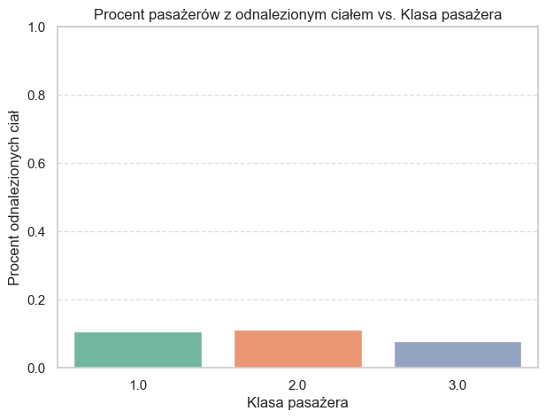

Nie ma wyraźnej różnicy między w ilości odnalezionych ciał pasażerów poszczególnych klas

Pasażerowie drugiej klasy mieli najwyższy odsetek odnalezionych ciał spośród wszystkich klas. Może to wynikać z ich lokalizacji na statku – być może znajdowali się w rejonach, które zostały stosunkowo szybko przeszukane podczas akcji ratunkowej, albo ich ciała wypłynęły i zostały odnalezione w większej liczbie.

Pierwsza i trzecia klasa mają niższy odsetek odnalezionych ciał, przy czym trzecia klasa – najniższy:

W przypadku trzeciej klasy może to wynikać z trudniejszego dostępu do pokładów ewakuacyjnych i głębszego umiejscowienia kabin (ciała mogły pozostać we wraku).

W przypadku pierwszej klasy – możliwe, że więcej osób z tej grupy zostało uratowanych, więc liczba odnalezionych ciał była po prostu mniejsza.

# EDA6 - analiza wartości odstających

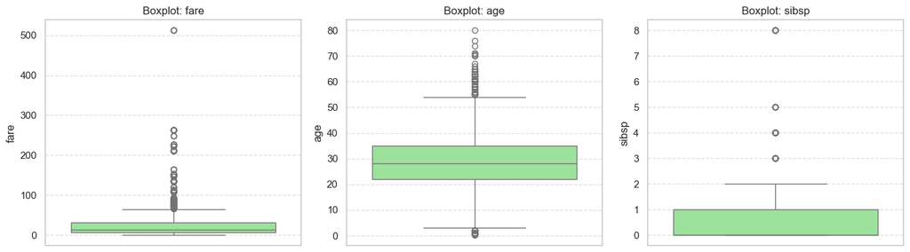

Zmienna koszt biletu (fare) – posiada dużo wartości odstających z prawej strony (tzw. prawoskośny rozkład). Kilkudziesięciu pasażerów zapłaciło więcej niż 100 funtów, co znacząco odstaje od typowego poziomu.

Wiek (age) – mniej wartości odstających, choć można dostrzec kilka osób w wieku powyżej 70 lat.

# WNIOSKI KOŃCOWE

1. Płeć pasażera miała zdecydowany wpływ na przeżywalność. Kobiety miały znacznie wyższy współczynnik przeżycia, co wskazuje na realizację zasady „kobiety i dzieci najpierw”.
2. Wiek również miał znaczenie – dzieci (0–12 lat) były znacznie częściej przypisane do łodzi ratunkowych, a pasażerowie w wieku 20–40 lat rzadziej. Seniorzy (60+) nie mieli szczególnie wysokiego udziału w grupie uratowanych – wbrew początkowym hipotezom.
3. Klasa biletu istotnie wpływała na szansę przeżycia. Pasażerowie 1 klasy przeżywali częściej niż pasażerowie klasy 3 – co może wynikać z lepszego dostępu do szalup ratunkowych i wyższej priorytetyzacji podczas ewakuacji.
4. Cena biletu korelowała z przeżywalnością – im wyższa cena, tym większe szanse przeżycia. Najdroższe bilety (powyżej 100 funtów) były rzadkie, ale miały bardzo wysoki współczynnik przeżycia. Tu jednak warto zaznaczyć, że niektórzy pasażerowie podróżowali grupowo na jednym bilecie – dlatego bardziej sprawiedliwym wskaźnikiem była średnia cena biletu na osobę. Nawet wtedy utrzymała się zależność: wyższy koszt na osobę = wyższe szanse na przeżycie.
5. Port zaokrętowania również miał pewien wpływ na przeżywalność. Najwyższe wskaźniki odnotowano wśród pasażerów wsiadających w Cherbourgu (C), co mogło wynikać z tego, że stamtąd wsiadało najwięcej pasażerów klasy 1.
6. Lokalizacja kabiny była silnie skorelowana z przeżyciem. Pasażerowie z kabinami oznaczonymi literami mieli znacznie większe szanse przeżycia. Osoby bez przydzielonej kabiny (oznaczone jako „Nieprzydzielona”) przeżywały zdecydowanie rzadziej.
7. Większość pasażerów z miejscem docelowym w Ameryce Północnej pochodziła z klasy 1. To sugeruje, że podróżowali w celach biznesowych lub migracyjnych, dysponując większymi środkami finansowymi – co mogło wpływać na ich szanse przeżycia.
8. Analiza łodzi ratunkowych pokazała, że nie wszystkie łodzie były wykorzystywane w równym stopniu. Obecność w łodzi ratunkowej zależała od płci i wieku. Kobiety i dzieci miały znacznie wyższy udział, co potwierdza wcześniejsze wnioski. Zastosowana zasada pierwszeństwa była respektowana – choć nie zawsze konsekwentnie.